# Final Individual Project

Hazel McLester

2026-05-03

#Loading in any packages I might need

```r
library(tidyverse)
library(stringr)
library(lubridate)
```

#Loading the data set into my script

```r
plant_pollinators<-read.csv(("SA02601_v6.csv"),
                            stringsAsFactors = FALSE)
#I am keeping strings as factors as false since I have so much non numerical data
```

#Going through the names to see how I might need to adjust them

```r
colnames(plant_pollinators)
```

```
##  [1] "DBCODE"     "ENTITY"     "COMPLEX"    "MEADOW"     "PLOT_ID"
##  [6] "YEAR"       "SAMPLEDATE" "WATCH"      "OBSERVER"   "PLOT"
## [11] "START_TIME" "END_TIME"   "MINUTE"     "CLOUDS"     "WIND"
## [16] "TEMP"       "PPI_STATUS" "NO_INT"     "PLTSP_CODE" "PLTSP_NAME"
## [21] "VISSP_CODE" "VISSP_NAME" "VISSP_TYPE" "REF_NO"     "VISSP_NO"
## [26] "QC_NOTES"
```

#Getting a full idea of all the types of observations I have

```r
str(plant_pollinators)
```

```
## 'data.frame':    74942 obs. of  26 variables:
##  $ DBCODE    : chr  "SA026" "SA026" "SA026" "SA026" ...
##  $ ENTITY    : int  1 1 1 1 1 1 1 1 1 1 ...
##  $ COMPLEX   : chr  "Bunchgrass" "Bunchgrass" "Bunchgrass" "Bunchgrass" ...
##  $ MEADOW    : chr  "BD" "BD" "BD" "BD" ...
##  $ PLOT_ID   : chr  "BGD01" "BGD01" "BGD01" "BGD01" ...
##  $ YEAR      : int  2011 2011 2011 2011 2011 2011 2011 2011 2011 2011 ...
##  $ SAMPLEDATE: chr  "2011-07-24" "2011-07-24" "2011-07-24" "2011-07-24" ...
##  $ WATCH     : num  2 2 2 2 2 2 2 2 2 2 ...
##  $ OBSERVER  : chr  NA NA NA NA ...
##  $ PLOT      : int  1 1 1 1 1 1 1 1 1 1 ...
##  $ START_TIME: int  NA NA NA NA NA NA NA NA NA NA ...
##  $ END_TIME  : int  NA NA NA NA NA NA NA NA NA NA ...
##  $ MINUTE    : int  1 1 1 1 1 2 2 2 3 3 ...
##  $ CLOUDS    : chr  "S" "S" "S" "S" ...
##  $ WIND      : chr  "ST" "ST" "ST" "ST" ...
##  $ TEMP      : int  NA NA NA NA NA NA NA NA NA NA ...
##  $ PPI_STATUS: int  1 1 1 1 1 1 1 1 1 1 ...
##  $ NO_INT    : int  2 1 2 2 2 1 1 1 2 2 ...
##  $ PLTSP_CODE: chr  "ACHIMILL" "ACHIMILL" "ERIGFOLI" "ERIGFOLI" ...
##  $ PLTSP_NAME: chr  "Achillea millefolium" "Achillea millefolium" "Erigeron foliosus" "Erigeron foliosus" ...
##  $ VISSP_CODE: chr  "EPICPUNC" "EVYLS5M" "MUSCGEN3" "MUSCGEN3" ...
##  $ VISSP_NAME: chr  "Epicauta puncticollis" "Evylaeus sp 5M" "Muscoid genus 3" "Muscoid genus 3" ...
##  $ VISSP_TYPE: chr  "predaceous beetle" "halictine bee" "herbivorous muscoid fly" "herbivorous muscoid fly" ...
##  $ REF_NO    : chr  NA NA NA NA ...
##  $ VISSP_NO  : int  1 1 1 2 1 1 1 1 1 1 ...
##  $ QC_NOTES  : chr  "" "" "" "" ...
```

```r
summary(plant_pollinators)
```

```
##     DBCODE              ENTITY    COMPLEX             MEADOW
##  Length:74942       Min.   :1   Length:74942       Length:74942
##  Class :character   1st Qu.:1   Class :character   Class :character
##  Mode  :character   Median :1   Mode  :character   Mode  :character
##                     Mean   :1
##                     3rd Qu.:1
##                     Max.   :1
##
##    PLOT_ID               YEAR       SAMPLEDATE            WATCH
##  Length:74942       Min.   :2011   Length:74942       Min.   :0.500
##  Class :character   1st Qu.:2013   Class :character   1st Qu.:2.000
##  Mode  :character   Median :2015   Mode  :character   Median :3.000
##                     Mean   :2015                      Mean   :2.887
##                     3rd Qu.:2017                      3rd Qu.:4.000
##                     Max.   :2021                      Max.   :7.000
##
##    OBSERVER              PLOT          START_TIME       END_TIME
##  Length:74942       Min.   : 1.000   Min.   : 100    Min.   : 918
##  Class :character   1st Qu.: 3.000   1st Qu.:1050    1st Qu.:1110
##  Mode  :character   Median : 5.000   Median :1154    Median :1216
##                     Mean   : 5.417   Mean   :1199    Mean   :1227
##                     3rd Qu.: 8.000   3rd Qu.:1328    3rd Qu.:1336
##                     Max.   :10.000   Max.   :1848    Max.   :1631
##                                      NA's   :10856   NA's   :67441
##      MINUTE          CLOUDS              WIND                TEMP
##  Min.   : 1.000   Length:74942       Length:74942       Min.   :10.00
##  1st Qu.: 3.000   Class :character   Class :character   1st Qu.:20.00
##  Median : 7.000   Mode  :character   Mode  :character   Median :24.00
##  Mean   : 7.166                                         Mean   :23.73
##  3rd Qu.:11.000                                         3rd Qu.:27.00
##  Max.   :15.000                                         Max.   :44.00
##  NA's   :260                                            NA's   :28503
##    PPI_STATUS         NO_INT         PLTSP_CODE         PLTSP_NAME
##  Min.   :0.0000   Min.   :  0.000   Length:74942       Length:74942
##  1st Qu.:1.0000   1st Qu.:  1.000   Class :character   Class :character
##  Median :1.0000   Median :  1.000   Mode  :character   Mode  :character
##  Mean   :0.8143   Mean   :  2.692
##  3rd Qu.:1.0000   3rd Qu.:  3.000
##  Max.   :1.0000   Max.   :225.000
##                   NA's   :53
##   VISSP_CODE         VISSP_NAME         VISSP_TYPE           REF_NO
##  Length:74942       Length:74942       Length:74942       Length:74942
##  Class :character   Class :character   Class :character   Class :character
##  Mode  :character   Mode  :character   Mode  :character   Mode  :character
##
##
##
##
##     VISSP_NO        QC_NOTES
##  Min.   : 1.000   Length:74942
##  1st Qu.: 1.000   Class :character
##  Median : 1.000   Mode  :character
##  Mean   : 1.714
##  3rd Qu.: 2.000
##  Max.   :35.000
##
```

```r
head(plant_pollinators)
```

```
##   DBCODE ENTITY    COMPLEX MEADOW PLOT_ID YEAR SAMPLEDATE WATCH OBSERVER PLOT
## 1  SA026      1 Bunchgrass     BD   BGD01 2011 2011-07-24     2     <NA>    1
## 2  SA026      1 Bunchgrass     BD   BGD01 2011 2011-07-24     2     <NA>    1
## 3  SA026      1 Bunchgrass     BD   BGD01 2011 2011-07-24     2     <NA>    1
## 4  SA026      1 Bunchgrass     BD   BGD01 2011 2011-07-24     2     <NA>    1
## 5  SA026      1 Bunchgrass     BD   BGD01 2011 2011-07-24     2     <NA>    1
## 6  SA026      1 Bunchgrass     BD   BGD01 2011 2011-07-24     2     <NA>    1
##   START_TIME END_TIME MINUTE CLOUDS WIND TEMP PPI_STATUS NO_INT PLTSP_CODE
## 1         NA       NA      1      S   ST   NA          1      2   ACHIMILL
## 2         NA       NA      1      S   ST   NA          1      1   ACHIMILL
## 3         NA       NA      1      S   ST   NA          1      2   ERIGFOLI
## 4         NA       NA      1      S   ST   NA          1      2   ERIGFOLI
## 5         NA       NA      1      S   ST   NA          1      2   ERIGFOLI
## 6         NA       NA      2      S   ST   NA          1      1   ACHIMILL
##             PLTSP_NAME VISSP_CODE            VISSP_NAME              VISSP_TYPE
## 1 Achillea millefolium   EPICPUNC Epicauta puncticollis       predaceous beetle
## 2 Achillea millefolium    EVYLS5M        Evylaeus sp 5M           halictine bee
## 3    Erigeron foliosus   MUSCGEN3       Muscoid genus 3 herbivorous muscoid fly
## 4    Erigeron foliosus   MUSCGEN3       Muscoid genus 3 herbivorous muscoid fly
## 5    Erigeron foliosus   TRICORNA     Trichodes ornatus    bee-parasitic beetle
## 6 Achillea millefolium   ANTHASP1         Anthaxia sp 1      herbivorous beetle
##   REF_NO VISSP_NO QC_NOTES
## 1   <NA>        1
## 2   <NA>        1
## 3   <NA>        1
## 4   <NA>        2
## 5   <NA>        1
## 6   <NA>        1
```

#Convert all titles to lowercase, so they are a more standard format

```r
names(plant_pollinators) <- str_to_lower(names(plant_pollinators))
```

#Replace spaces or weird characters with underscore, to match naming formats

```r
names(plant_pollinators) <- gsub(" ", "_", names(plant_pollinators))
names(plant_pollinators) <- gsub("\\.", "_", names(plant_pollinators))
```

#Checking the names after adjusting them

```r
names(plant_pollinators)
```

```
##  [1] "dbcode"     "entity"     "complex"    "meadow"     "plot_id"
##  [6] "year"       "sampledate" "watch"      "observer"   "plot"
## [11] "start_time" "end_time"   "minute"     "clouds"     "wind"
## [16] "temp"       "ppi_status" "no_int"     "pltsp_code" "pltsp_name"
## [21] "vissp_code" "vissp_name" "vissp_type" "ref_no"     "vissp_no"
## [26] "qc_notes"
```

#To ensure that there are no human error extra characters, we are using the #str_trim function on the priority columns

```r
plant_pollinators <- plant_pollinators %>%
  mutate(
    pltsp_name = str_trim(pltsp_name),
    vissp_name = str_trim(vissp_name),
    meadow = str_trim(meadow),
    observer = str_trim(observer))
```

#Remove any columns that are difficult to understand or are not applicable, etc

```r
plant_pollinators <- plant_pollinators %>%
  select( -start_time, -end_time, -pltsp_code,-vissp_code,
          -ref_no, -vissp_no,-qc_notes)
```

#Remove rows missing species info

```r
plant_pollinators <- plant_pollinators %>%
  filter(!is.na(pltsp_name),
         !is.na(vissp_name))
```

#Remove empty strings

```r
plant_pollinators <- plant_pollinators %>%
  filter(pltsp_name != "",
         vissp_name != "")
```

#Change any names that are very difficult to understand

```r
plant_pollinators<-plant_pollinators %>%
  rename(plant_species=pltsp_name,
         visiter_name=vissp_name,
         visiter_type=vissp_type)
```

#I do not understand what the acronyms mean, so I need to make a list of all of #them, so I can change the inputs

```r
unique(plant_pollinators$wind)
```

```
## [1] "ST" "BR" NA
```

#For wind there is ST and BR #Convert wind Acronyms to understandable values

```r
plant_pollinators <- plant_pollinators %>%
  mutate(
    wind_category = case_when(
      wind == "ST" ~ "still (no wind)",
      wind == "BR" ~ "breeze",
      TRUE ~ "unknown"))
```

#Remove original Wind column

```r
plant_pollinators <- plant_pollinators %>%
  select(-wind)
```

#For clouds there is S, PC, C, and SH

```r
unique(plant_pollinators$clouds)
```

```
## [1] "S"  "PC" "SH" "C"  NA
```

#Convert cloud acroynms to understandable values

```r
plant_pollinators <- plant_pollinators %>%
  mutate(
    cloud_category = case_when(
      clouds == "S" ~ "sunny",
      clouds == "PC" ~ "partly cloudy",
      clouds == "C" ~ "cloudy",
      clouds == "SH" ~ "showers",
      TRUE ~ "unknown"))
```

#Remove original cloud column

```r
plant_pollinators<-plant_pollinators %>%
  select(-clouds)
```

#Check unique values for key variables

```r
unique(plant_pollinators$meadow)
```

```
##  [1] "BD"  "BH"  "BS"  "CNE" "CNM" "CNT" "CPB" "CPM" "CPR" "CPS" "M2"  "NE"
## [13] "LB"  "LM"  "LO"  "LS"  "RP1" "RP2"
```

```r
unique(plant_pollinators$visiter_type)
```

```
##  [1] "predaceous beetle"              "halictine bee"
##  [3] "herbivorous muscoid fly"        "bee-parasitic beetle"
##  [5] "herbivorous beetle"             "decomposer hover-fly"
##  [7] "predaceous hover-fly"           "social bee"
##  [9] "solitary bee"                   "herbivorous butterfly; diurnal"
## [11] "predaceous wasp"                "omnivorous ant"
## [13] "bee-predator beetle"            "predaceous muscoid fly"
## [15] "semi-social bee"                "herbivorous true-bug"
## [17] "hummingbird"                    "herbivore-parasitic muscoid fl"
## [19] "herbivorous grasshopper"        "bee-predaceous bee-fly"
## [21] "predaceous bee-fly"             "kleptoparasitic bee"
## [23] "herbivore-parasitic bee-fly"    "misc fly"
## [25] "herbivorous moth; nocturnal"    "bee-parasitic wasp"
## [27] "pollinator-predaceous spider"   "predator-parasitic bee-fly"
## [29] "bee-predaceous wasp"            "detritivorous primitive fly"
```

[output cut: 25 more lines]

#I want to change the order of the columns to improve readability #First I will move all of the identification columns together

```r
plant_pollinators<-plant_pollinators %>%
  relocate(plot_id, .after=dbcode)%>%
  relocate(year,.after=dbcode)
```

#Now I want to put the columns in the same order as in the id

```r
unique(plant_pollinators$plot_id)
```

```
##   [1] "BGD01" "BGD02" "BGD03" "BGD04" "BGD05" "BGD06" "BGD07" "BGD08" "BGD09"
##  [10] "BGD10" "BGH01" "BGH02" "BGH03" "BGH04" "BGH05" "BGH06" "BGH07" "BGH08"
##  [19] "BGH09" "BGH10" "BGS01" "BGS02" "BGS03" "BGS04" "BGS05" "BGS06" "BGS07"
##  [28] "BGS08" "BGS09" "BGS10" "CNE01" "CNE02" "CNE03" "CNE04" "CNE05" "CNE06"
##  [37] "CNE07" "CNE08" "CNE09" "CNE10" "CNM01" "CNM02" "CNM03" "CNM04" "CNM05"
##  [46] "CNM06" "CNM07" "CNM08" "CNM09" "CNM10" "CNT01" "CNT02" "CNT03" "CNT04"
##  [55] "CNT05" "CNT06" "CNT07" "CNT08" "CNT09" "CNT10" "CPB01" "CPB02" "CPB03"
##  [64] "CPB04" "CPB05" "CPB06" "CPB07" "CPB08" "CPB09" "CPB10" "CPM01" "CPM02"
##  [73] "CPM03" "CPM04" "CPM05" "CPM06" "CPM07" "CPM08" "CPM09" "CPM10" "CPR01"
##  [82] "CPR02" "CPR03" "CPR04" "CPR05" "CPR06" "CPR07" "CPR08" "CPR09" "CPR10"
##  [91] "CPS01" "CPS02" "CPS03" "CPS04" "CPS05" "CPS06" "CPS07" "CPS08" "CPS09"
## [100] "CPS10" "FM201" "FM202" "FM203" "FM204" "FM205" "FM206" "FM207" "FM208"
## [109] "FM209" "FM210" "FNE01" "FNE02" "FNE03" "FNE04" "FNE05" "FNE06" "FNE07"
## [118] "FNE08" "FNE09" "FNE10" "LOB01" "LOB02" "LOB03" "LOB04" "LOB05" "LOB06"
## [127] "LOB07" "LOB08" "LOB09" "LOB10" "LOM01" "LOM02" "LOM03" "LOM04" "LOM05"
## [136] "LOM06" "LOM07" "LOM08" "LOM09" "LOM10" "LOO01" "LOO02" "LOO03" "LOO04"
## [145] "LOO05" "LOO06" "LOO07" "LOO08" "LOO09" "LOO10" "LOS01" "LOS02" "LOS03"
## [154] "LOS04" "LOS05" "LOS06" "LOS07" "LOS08" "LOS09" "LOS10" "RP101" "RP102"
## [163] "RP103" "RP104" "RP105" "RP106" "RP107" "RP108" "RP109" "RP110" "RP201"
## [172] "RP202" "RP203" "RP204" "RP205" "RP206" "RP207" "RP208" "RP209" "RP210"
```

```r
unique(plant_pollinators$meadow)
```

```
##  [1] "BD"  "BH"  "BS"  "CNE" "CNM" "CNT" "CPB" "CPM" "CPR" "CPS" "M2"  "NE"
## [13] "LB"  "LM"  "LO"  "LS"  "RP1" "RP2"
```

```r
plant_pollinators<-plant_pollinators%>%
  relocate(complex,.after=plot_id)%>%
  relocate(meadow,.after=complex)%>%
  relocate(plot,.after=meadow)
```

#Now we are going to move all of the abiotic factors together

```r
plant_pollinators<-plant_pollinators%>%
  relocate(wind_category,.after=temp)%>%
  relocate(cloud_category,.after=wind_category)
```

#Code to go through and edit to how I want it #### #Counting species interactions #Counting how many interactions

```r
interaction_counts <- plant_pollinators %>%
  group_by(plant_species,
           visiter_name) %>%
  summarise(visits = n()) %>%
  ungroup()
```

#Counting how many visits per plant species

```r
plant_visits <- plant_pollinators %>%
  group_by(plant_species) %>%
  summarise(total_visits = n()) %>%
  ungroup()
```

#Counting how many visits per visitor species

```r
pollinator_visits <- plant_pollinators %>%
  group_by(visiter_name) %>%
  summarise(total_visits = n()) %>%
  ungroup()
```

#Top species code

```r
top_plants <- plant_visits %>%
  arrange(desc(total_visits)) %>%
  slice(1:10)
top_pollinators <- pollinator_visits %>%
  arrange(desc(total_visits)) %>%
  slice(1:10)
```

#Visits by meadow

```r
visits_by_meadow <- plant_pollinators %>%
  group_by(meadow) %>%
  summarise(visits = n()) %>%
  ungroup()
```

#Visits by pollinator type

```r
visits_by_type <- plant_pollinators %>%
  group_by(visiter_type) %>%
  summarise(visits = n()) %>%
  ungroup()
```

#Visits over time

```r
visits_by_year <- plant_pollinators %>%
  group_by(year) %>%
  summarise(visits = n())%>%
  ungroup()
```

#Visits by temp

```r
visits_by_temp <- plant_pollinators %>%
  group_by(temp) %>%
  summarise(visits = n()) %>%
  ungroup()
```

#Top plants figure. Shows which plant species are most prevelent in the study.

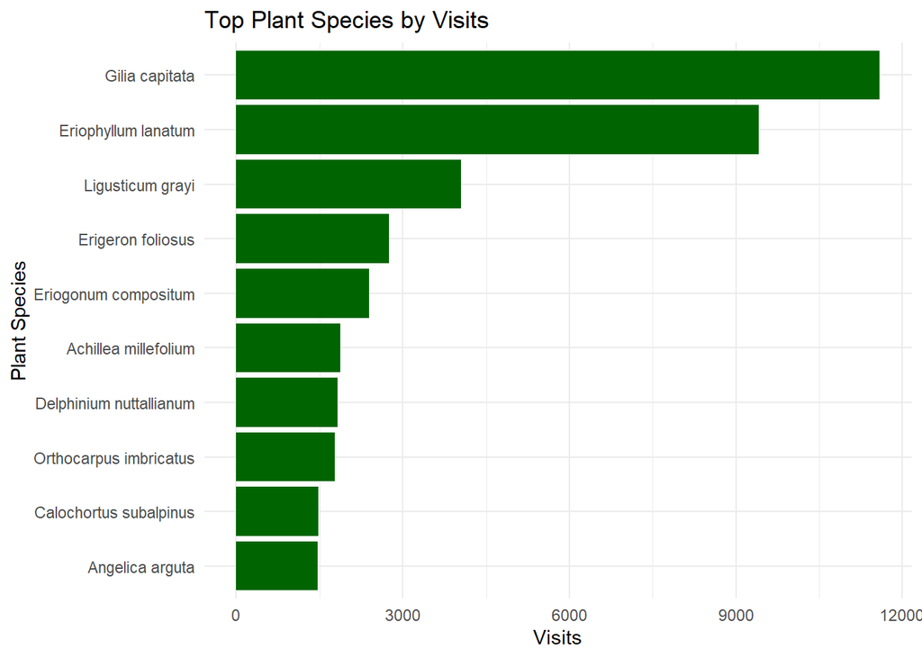

```r
ggplot(top_plants, aes(x = reorder(plant_species, total_visits), y = total_visits)) +
  geom_col(fill = "darkgreen") +
  coord_flip() +
  labs(
    title = "Top Plant Species by Visits",
    x = "Plant Species",
    y = "Visits"
  ) +
  theme_minimal()
```

#Top Pollinators Figure. Shows which pollinators are the most prevelent in the #study.

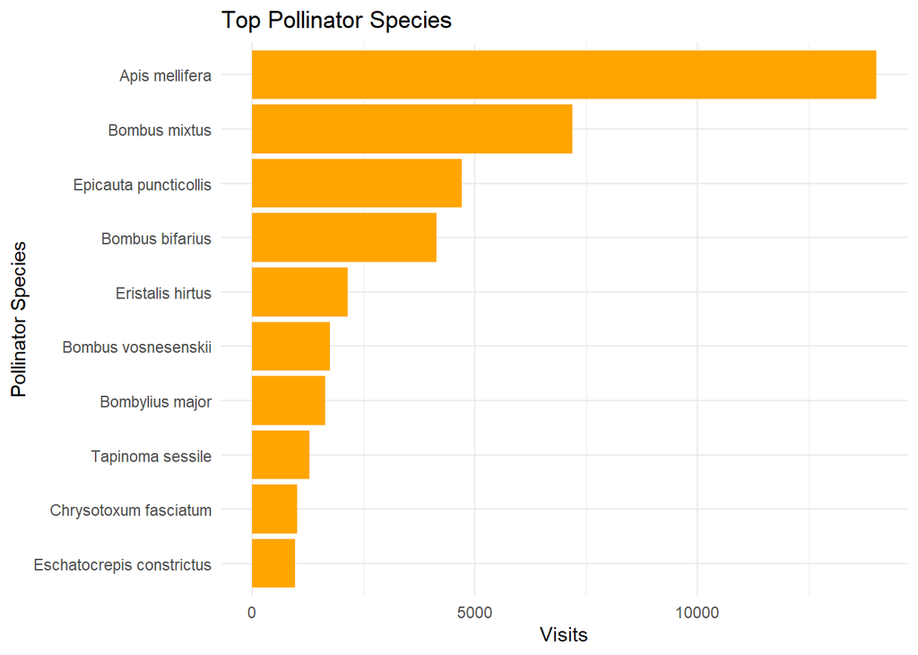

```r
ggplot(top_pollinators, aes(x = reorder(visiter_name, total_visits), y = total_visits)) +
  geom_col(fill = "orange") +
  coord_flip() +
  labs(
    title = "Top Pollinator Species",
    x = "Pollinator Species",
    y = "Visits"
  ) +
  theme_minimal()
```

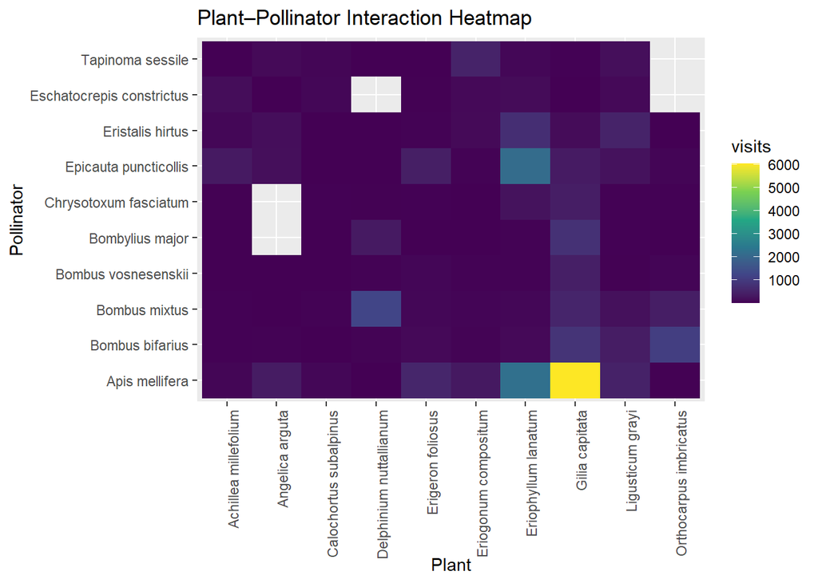

```r
top_interactions <- interaction_counts %>%
  filter(plant_species %in% top_plants$plant_species,
         visiter_name %in% top_pollinators$visiter_name)
ggplot(top_interactions,
       aes(x = plant_species,
           y = visiter_name,
           fill = visits)) +
  geom_tile() +
  scale_fill_viridis_c() +
  labs(
    title = "Plant–Pollinator Interaction Heatmap",
    x = "Plant",
    y = "Pollinator"
  ) +
  theme(axis.text.x = element_text(angle = 90, hjust = 1))
```

#Visits by meadow Figure. Given more information about what is in each meadow #this figure can be used to show what species grow and live in what sorts of #environments.

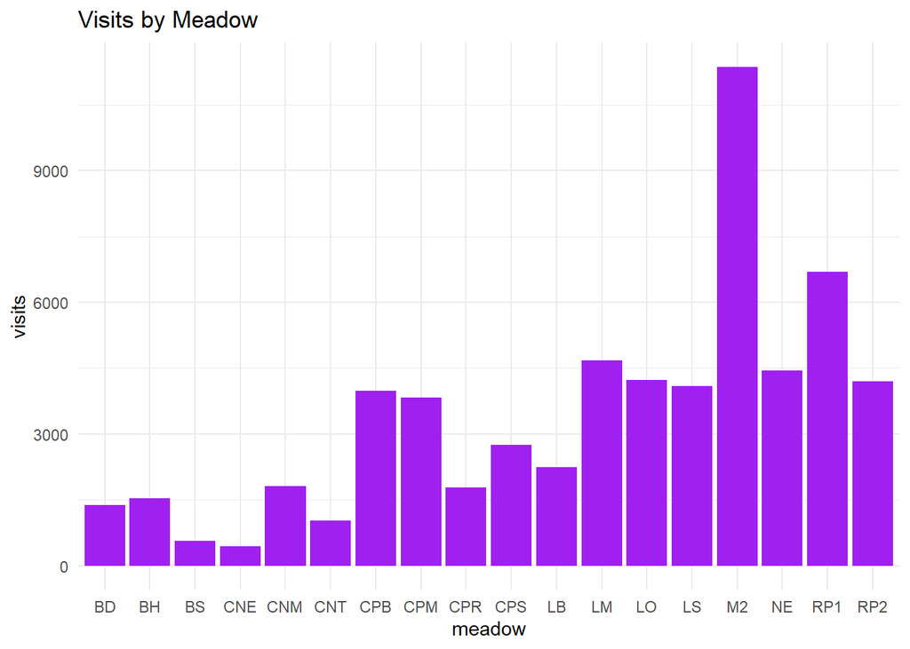

```r
ggplot(visits_by_meadow, aes(x = meadow, y = visits)) +
  geom_col(fill = "purple") +
  labs(title = "Visits by Meadow") +
  theme_minimal()
```

#Temperature influence on visitation Figure. Showing how when temperatures are #Too low or too high there is an influence on the number of pollinators.

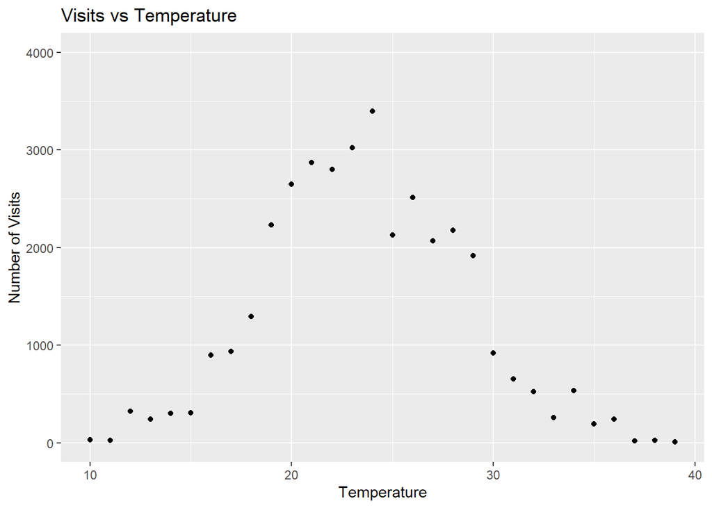

```r
ggplot(visits_by_temp, aes(x = temp, y = visits)) +
  geom_point() +
  labs(title = "Visits vs Temperature",
       x = "Temperature",
       y = "Number of Visits") +
  coord_cartesian(ylim = c(0, 4000))
```

```r
  theme_minimal()
```

[output not shown]

[output cut: 313 more lines]

[output not shown]

#individual project Introduction/Proposal

#link:https://portal.edirepository.org/nis/mapbrowse?packageid=knb-lter-and.5216.8 #Citation:Seo, E., J.A. Jones, R.A. Hutchinson, and V.W. Pfeiffer. 2022. Plant Pollinator data at HJ Andrews Experimental Forest, 2011 to 2021 ver 8. Environmental Data Initiative. https://doi.org/10.6073/pasta/eec55cbc3dbfc56428629773737ab3e5 (Accessed 2026-03-15).

#When it comes to cleaning this data the first thing I would do is remove any information that is extra or unnecessary for the end dataset. That means columns such as DBCode and entity will be merged, observer will be removed, notes will be removed. All of the id information might be condensed so that there is less visual clutter. For example there is both a plotId and plot column when the plotId includes the plot column so there does not need to be both. I will want to move the minute observed closer to the species of the plant and visitor. I also am going to figure out what plant species there is the most data for and use that species of plant as the basis for my figures. There are some variables that I do not understand what they mean so I will change the contents of wind and clouds to contain descriptions that make more sense. I will get rid of the species code and visitor code columns and change the names of the species name and visitor name to be easier to understand.I then want to take the data and produce a histogram that shows how many insects visit each species of plant. Then I would also like to make a dot plot that shows # of insects that arrive on a temperature gradient. To look at diversity overtime, I might need to make a mini dataset that contains summaries of how many occurrences per meadow per year there are, and this would be another data set that would benefit from choosing one species of plant rather than the many included in this data set.